# Conjoint - Customer Preferences for Opening a Current Account

## Conjoint - What is it?

**Conjoint analysis is a survey-based quantitative technique used to understand how customers make trade-offs between different attributes of a product or service.** Instead of asking respondents to evaluate features in isolation, conjoint presents realistic combinations (e.g. brand, interest rate, brand access, maintenance fee, card type) and observes the choices they make. By analysing these choices, the method estimates the relative importance of each attribute and the value customers assign to different levels, allowing banks to quantify preference drivers, simulate market scenarios, and design products that better align with customer needs.

In conjoint analysis, **attributes** are the key features or dimensions of a product or service that influence customer choice (such as brand, price, or branch access). **Levels** are the specific values or options that each attribute can take (for example, €0, €5, or €10 as levels of a monthly maintenance fee). While attributes define *what* aspects are being evaluated, levels define *how* those aspects are presented to respondents in the choice tasks.

## Dataset and Survey Example

The data used in this example are purely synthetic and serve illustrative purposes only. The current example contains the following attributes and levels:

**Conjoint design: attributes and levels**

| **Attribute** | **Levels** |
| --- | --- |
| Branch Access | Online only • Hybrid & full |
| Brand | Commerzbank • Raiffeisenbank • Deutsche Bank |
| Card Type | Debit only • Debit + Credit |
| Interest Rate on Balance | 1% • 2% • 3% |
| Maintenance Fee | €0 • €5 • €10 |

## Relative Importance

**Relative attribute importance** measures how much each attribute contributes to customers’ choice decisions compared to the others in the conjoint model. It is derived from the range of part-worth utilities within each attribute, capturing how strongly changes in that attribute influence choice. A higher relative importance indicates that customers are more sensitive to variations in that attribute, making it a stronger driver of preference, while lower importance suggests a more secondary or hygiene role in decision-making.

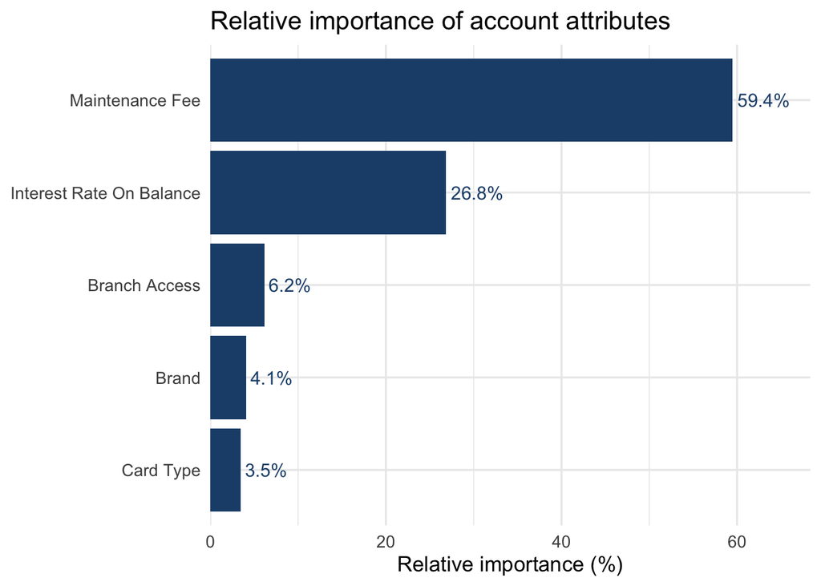

The most important attribute is the monthly account maintenance fee (59.4%), followed by the interest earned on the account (26.8%), access modality (6.2%), bank brand (4.1%), and card type (3.5%).

## Part-worth utilities

**Part-worth utilities** represent the relative value that respondents assign to each level of an attribute in a conjoint analysis. They quantify how much each specific option increases or decreases the likelihood of being chosen compared to a reference level within the same attribute. Part-worth utilities are expressed on a relative scale, meaning they are interpreted through differences between levels rather than as absolute values, and they capture the trade-offs consumers make when evaluating multiple features simultaneously.

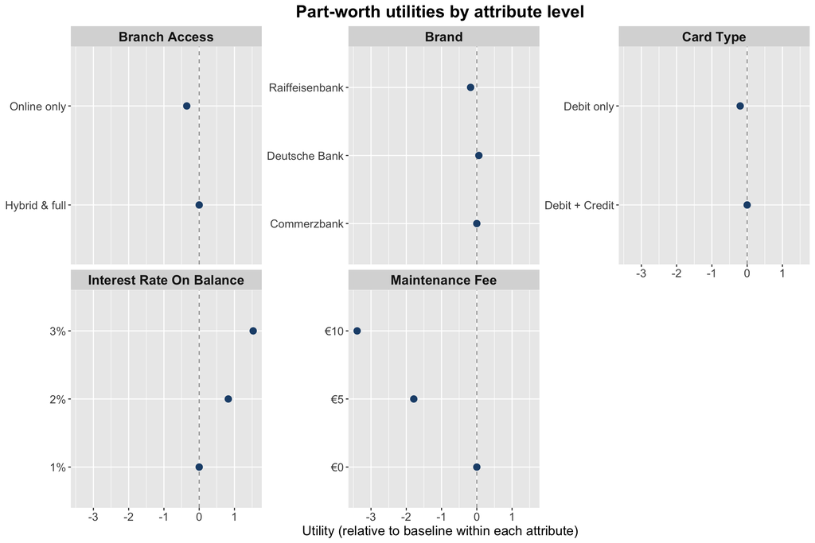

**The part-worth utilities plot shows the relative preference for each attribute level within its own attribute. Levels with higher utilities increase the likelihood of choice, while levels with lower utilities reduce it, always interpreted relative to the reference (baseline) level, which is normalized to zero.** The distance between points within the same attribute reflects the strength of the trade-off: larger spreads indicate that changing levels has a stronger impact on choice, whereas small differences suggest a more hygiene or secondary role. A clear example is the interest rate on balance, where the 1% level serves as the baseline, and higher interest rates are associated with increasingly positive utilities, indicating a stronger preference.

After understanding which attributes matter most and how individual levels are valued, the next step is to translate these preferences into monetary terms through willingness-to-pay estimates.

## Willingness to pay

**Willingness to Pay (WTP) represents the monetary value that customers assign to a specific feature or attribute level, expressed as the maximum amount they are willing to pay to obtain it, or conversely, the compensation they would require to give it up.** In conjoint analysis, WTP is derived by relating the utility of a given level to the utility of price (or fee), translating preference trade-offs into a common monetary scale that directly supports pricing and product design decisions.

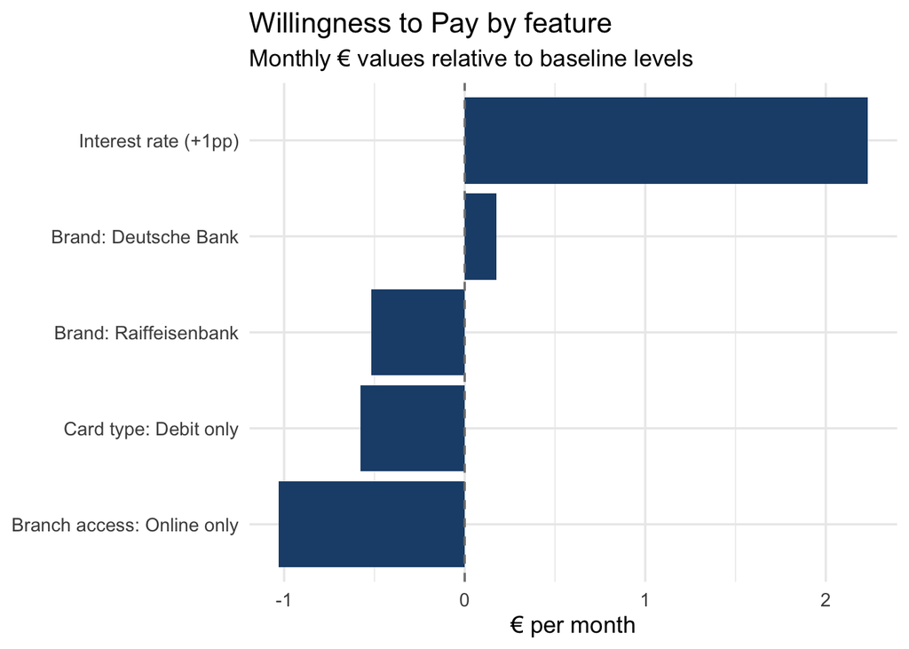

**Positive values indicate features customers are willing to pay for, while negative values represent the monthly fee reduction required to compensate for less preferred features.**

The results show that pricing-related features dominate account choice. Customers are willing to pay around €2.2 per month for each additional percentage point of interest, highlighting the strong role of interest as a value driver. Service-related attributes mainly act as penalties when removed: an online-only model reduces perceived value by about €1 per month, and offering only a debit card leads to a smaller loss of around €0.6. Brand effects are comparatively modest, with Deutsche Bank showing a slight premium and Raiffeisenbank a small discount, confirming that brand influences choice but is secondary to pricing and core service features.

## Scenario Simulations

### Scenario 1 - Pricing vs interest trade-off

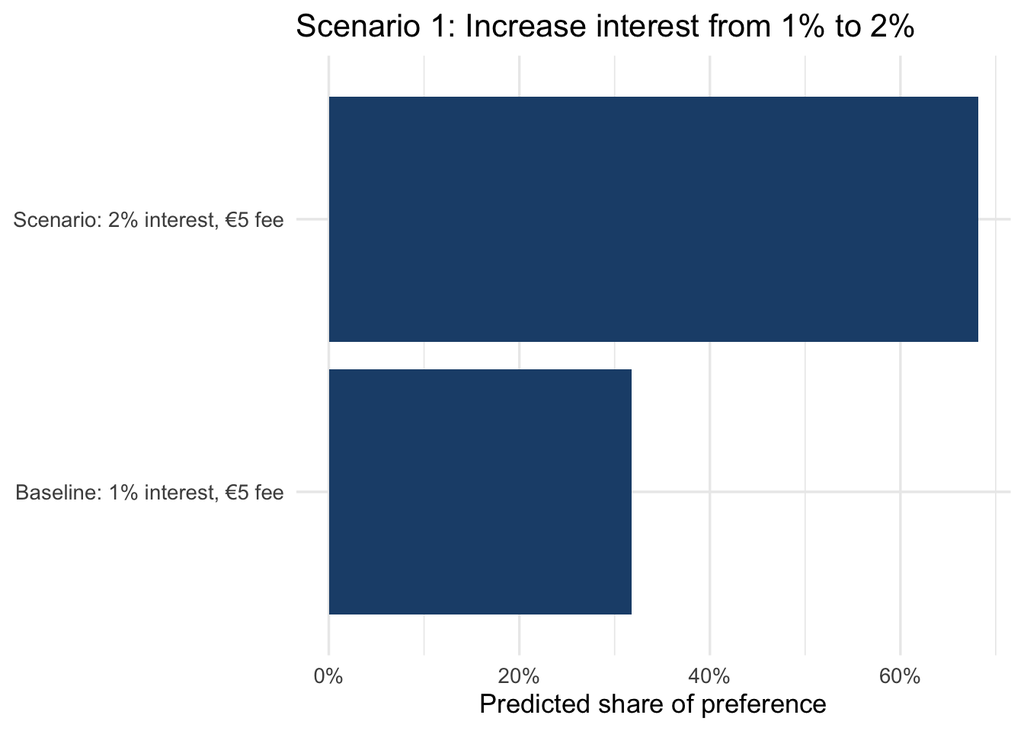

**Scenario simulations show that increasing the interest rate from 1% to 2%, while keeping the monthly fee constant, leads to a substantial shift in preference, increasing predicted share from 32% to 68%**.

### Scenario 2 - Online vs. Hybrid

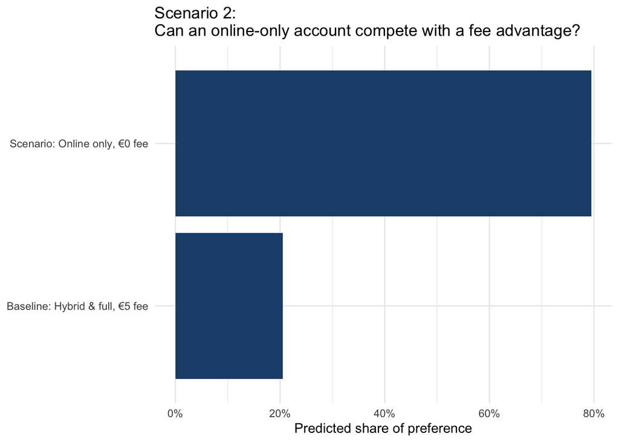

**A digital-only current account can strongly outperform a hybrid offer if it is paired with a zero monthly fee**, suggesting that price reductions more than offset the loss of branch access.

### Scenario 3 - Brand effect holding the product constant

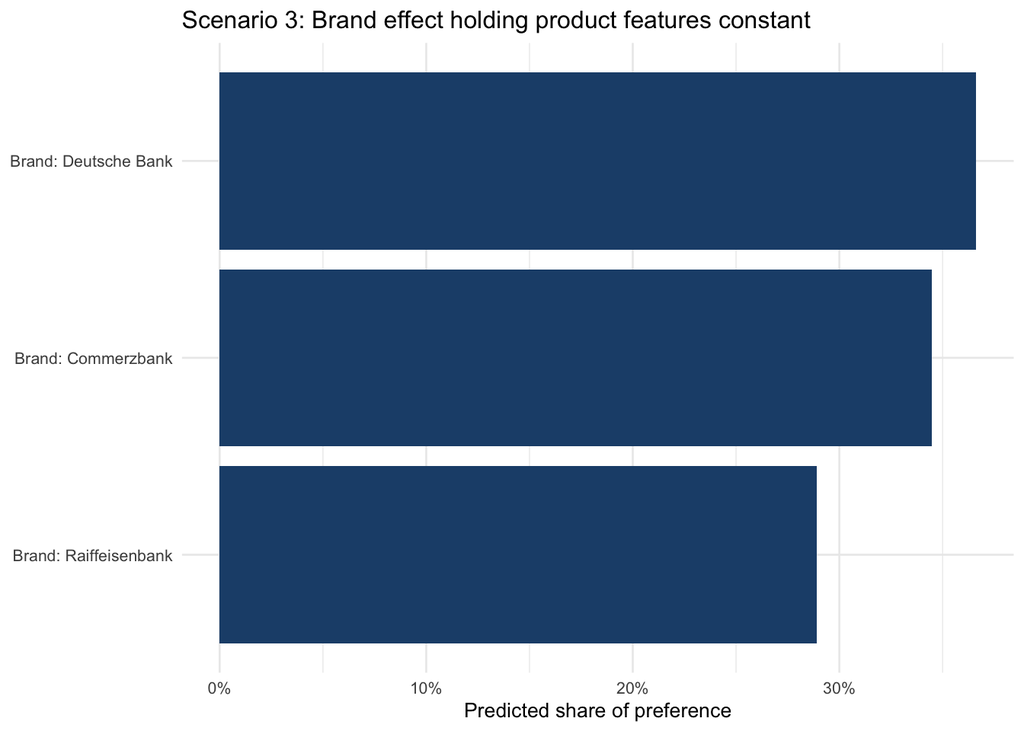

**Holding pricing and product features constant, brand differences lead to relatively small shifts in preference.** Deutsche Bank shows a modest brand premium, capturing around 36.7% of preference share, followed closely by Commerzbank at 34.4%, while Raiffeisenbank trails slightly with 28.9%. This indicates that while brand reputation influences choice, its impact is clearly secondary compared to pricing and core service attributes.

**This conjoint analysis demonstrates that customer choice for current accounts is primarily driven by pricing-related factors, particularly the monthly maintenance fee and the interest rate on balance.** While service features such as branch access and card type influence preferences, they mainly act as trade-offs that require monetary compensation when removed. Brand effects are present but comparatively modest, indicating that product design and pricing decisions outweigh brand positioning in shaping customer choice. Overall, the analysis shows how conjoint methods can translate customer preferences into actionable pricing and product design insights for retail banking.